# Blood pressure

Dodzia

A study was conducted into the effectiveness of a new blood pressure treatment at different doses. Patients’ blood pressures were measured initially, before 4 weeks of treatment with the new drug. Each patient was randomly allocated one of 4 different dose levels. At the end of the treatment period, the patients’ blood pressures were remeasured and the change was recorded.

```r
blood <- read.csv("/data/pc3data1.csv")
```

[output not shown]

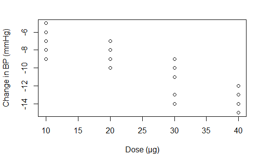

The relation appears to be linear. So we fit it

```r
summary(lm1)
```

```
Call:
lm(formula = BPchange ~ BPinit + Dose, data = blood)

Residuals:
     Min       1Q   Median       3Q      Max
-2.00688 -0.60590  0.02509  0.75888  2.30379

Coefficients:
             Estimate Std. Error t value Pr(>|t|)
(Intercept) -1.962512   0.910702  -2.155  0.03774 *
BPinit      -0.021542   0.006269  -3.436  0.00147 **
Dose        -0.190743   0.015527 -12.284 1.27e-14 ***
---
Signif. codes:  0 ‘***’ 0.001 ‘**’ 0.01 ‘*’ 0.05 ‘.’ 0.1 ‘ ’ 1

Residual standard error: 1.069 on 37 degrees of freedom
Multiple R-squared:  0.8386,    Adjusted R-squared:  0.8299
F-statistic: 96.13 on 2 and 37 DF,  p-value: 2.217e-15
```

The p-values are very small, advocating in favour of including Dose and BPinit in the model. We carry out a sequential ANOVA by calling anova() with 1 argument

```r
anova(lm1)
```

```
Analysis of Variance Table

Response: BPchange
          Df  Sum Sq Mean Sq F value    Pr(>F)
BPinit     1  47.214  47.214  41.349 1.646e-07 ***
Dose       1 172.313 172.313 150.907 1.269e-14 ***
Residuals 37  42.248   1.142
---
Signif. codes:  0 ‘***’ 0.001 ‘**’ 0.01 ‘*’ 0.05 ‘.’ 0.1 ‘ ’ 1
```

The sum of squares for the ANOVA table is calculated as follows: TotalSS is sum of entries in column “Sum Sq” RegSS is the sum of the sum of squares for BPinit and Dose ResidSS is stated explicitly above

a more elegant way to get this is

```r
RegrSS <- sum(SS[1:2]) # Regression sum of squares
```

[output not shown]

We now get the required degrees of freedom

```r
df <- a$Df
TotalDF <- sum(df) # Total degrees of freedom
RegrDF <- sum(df[1:2]) # Regression degrees of freedom
ResidDF <- df[3] # Residual degrees of freedom
```